# lab6

Author

Sarah Culhane

## Question 1

```r
#load neccessary libraries
library(tidyverse)
library(tidymodels)
library(powerjoin)
library(glue)
library(vip)
library(baguette)
#download all data and PDF
root  <- 'https://gdex.ucar.edu/dataset/camels/file'
download.file('https://gdex.ucar.edu/dataset/camels/file/camels_attributes_v2.0.pdf',
              'data/camels_attributes_v2.0.pdf')
types <- c("clim", "geol", "soil", "topo", "vege", "hydro")
# Where the files live online ...
remote_files  <- glue('{root}/camels_{types}.txt')
# where we want to download the data ...
local_files   <- glue('data/camels_{types}.txt')
walk2(remote_files, local_files, download.file, quiet = TRUE)
# Read and merge data
camels <- map(local_files, read_delim, show_col_types = FALSE)
camels <- power_full_join(camels ,by = 'gauge_id')
```

First, I downloaded all the necessary data into my data directory. From the documentation PDF, I was able to figure out that zero_q_freq represents the percentage of days within a given period during which the stream flow (Q) is zero, indicating no flow conditions.

# Question 2

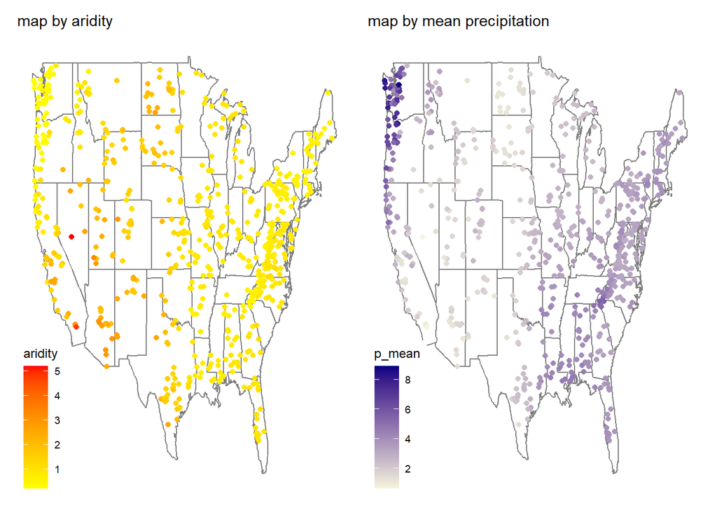

```r
# load neccessary library(ggplot2)
library(ggthemes)
library(patchwork)

# create map colored by aridity
map_aridity <- ggplot(data = camels, aes(x = gauge_lon, y = gauge_lat)) +
  borders("state", colour = "gray50") +
  geom_point(aes(color = aridity)) +
  scale_color_gradient(low = "yellow", high = "red") +
  labs(title = "map by aridity") +
  ggthemes::theme_map()

# create map colored by mean precipitation
map_p_mean <- ggplot(data = camels, aes(x = gauge_lon, y = gauge_lat)) +
  borders("state", colour = "gray50") +
  geom_point(aes(color = p_mean)) +
  scale_color_gradient(low = "beige", high = "navy") +
  labs(title = "map by mean precipitation") +
  ggthemes::theme_map()

# Combine the two maps side by side using patchwork
map_aridity + map_p_mean
```

I used the code above to make 2 maps of the sites, colored by aridity and the p_mean column.

# Question 3

```r
#run code so far from lab instructions
set.seed(123)
# Bad form to perform simple transformations on the outcome variable within a
# recipe. So, we'll do it here.
camels <- camels |>
  mutate(logQmean = log(q_mean))

# Generate the split
camels_split <- initial_split(camels, prop = 0.8)
camels_train <- training(camels_split)
camels_test  <- testing(camels_split)

camels_cv <- vfold_cv(camels_train, v = 10)

#preprocess recipe

# Create a recipe to preprocess the data
rec <-  recipe(logQmean ~ aridity + p_mean, data = camels_train) %>%
  # Log transform the predictor variables (aridity and p_mean)
  step_log(all_predictors()) %>%
  # Add an interaction term between aridity and p_mean
  step_interact(terms = ~ aridity:p_mean) |>
  # Drop any rows with missing values in the pred
  step_naomit(all_predictors(), all_outcomes())

# Prepare the data
baked_data <- prep(rec, camels_train) |>
  bake(new_data = NULL)

# Interaction with lm

#  Base lm sets interaction terms with the * symbol
lm_base <- lm(logQmean ~ aridity * p_mean, data = baked_data)
summary(lm_base)
```

```
Call:
lm(formula = logQmean ~ aridity * p_mean, data = baked_data)

Residuals:
     Min       1Q   Median       3Q      Max
-2.91162 -0.21601 -0.00716  0.21230  2.85706

Coefficients:
               Estimate Std. Error t value Pr(>|t|)
(Intercept)    -1.77586    0.16365 -10.852  < 2e-16 ***
aridity        -0.88397    0.16145  -5.475 6.75e-08 ***
p_mean          1.48438    0.15511   9.570  < 2e-16 ***
aridity:p_mean  0.10484    0.07198   1.457    0.146
---
Signif. codes:  0 '***' 0.001 '**' 0.01 '*' 0.05 '.' 0.1 ' ' 1

Residual standard error: 0.5696 on 531 degrees of freedom
Multiple R-squared:  0.7697,    Adjusted R-squared:  0.7684
F-statistic: 591.6 on 3 and 531 DF,  p-value: < 2.2e-16
```

```r
# Sanity Interaction term from recipe ... these should be equal!!
summary(lm(logQmean ~ aridity + p_mean + aridity_x_p_mean, data = baked_data))
```

```
Call:
lm(formula = logQmean ~ aridity + p_mean + aridity_x_p_mean,
    data = baked_data)

Residuals:
     Min       1Q   Median       3Q      Max
-2.91162 -0.21601 -0.00716  0.21230  2.85706

Coefficients:
                 Estimate Std. Error t value Pr(>|t|)
(Intercept)      -1.77586    0.16365 -10.852  < 2e-16 ***
aridity          -0.88397    0.16145  -5.475 6.75e-08 ***
p_mean            1.48438    0.15511   9.570  < 2e-16 ***
aridity_x_p_mean  0.10484    0.07198   1.457    0.146
---
Signif. codes:  0 '***' 0.001 '**' 0.01 '*' 0.05 '.' 0.1 ' ' 1

Residual standard error: 0.5696 on 531 degrees of freedom
Multiple R-squared:  0.7697,    Adjusted R-squared:  0.7684
F-statistic: 591.6 on 3 and 531 DF,  p-value: < 2.2e-16
```

```r
test_data <-  bake(prep(rec), new_data = camels_test)
test_data$lm_pred <- predict(lm_base, newdata = test_data)

# Define model
lm_model <- linear_reg() %>%
  # define the engine
  set_engine("lm") %>%
  # define the mode
  set_mode("regression")

# Instantiate a workflow ...
lm_wf <- workflow() %>%
  # Add the recipe
  add_recipe(rec) %>%
  # Add the model
  add_model(lm_model) %>%
  # Fit the model to the training data
  fit(data = camels_train)

# Extract the model coefficients from the workflow
summary(extract_fit_engine(lm_wf))$coefficients
```

```
                   Estimate Std. Error    t value     Pr(>|t|)
(Intercept)      -1.7758557 0.16364755 -10.851710 6.463654e-25
aridity          -0.8839738 0.16144589  -5.475357 6.745512e-08
p_mean            1.4843771 0.15511117   9.569762 4.022500e-20
aridity_x_p_mean  0.1048449 0.07198145   1.456555 1.458304e-01
```

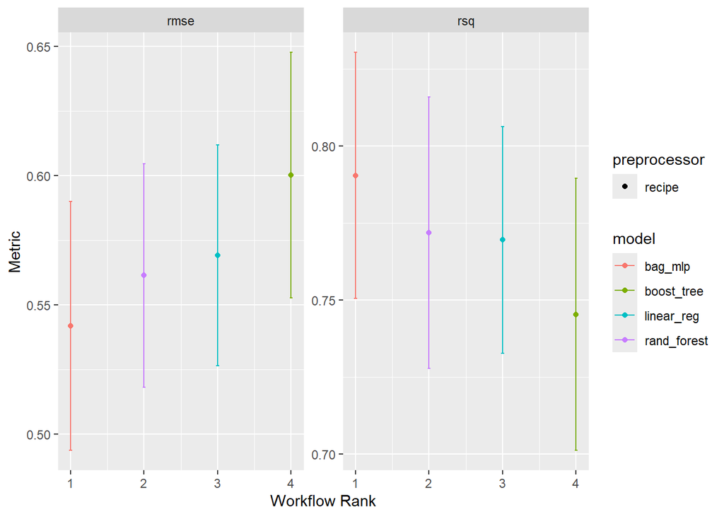

```r
library(baguette)
rf_model <- rand_forest() %>%
  set_engine("ranger", importance = "impurity") %>%
  set_mode("regression")

rf_wf <- workflow() %>%
  # Add the recipe
  add_recipe(rec) %>%
  # Add the model
  add_model(rf_model) %>%
  # Fit the model
  fit(data = camels_train)

# part 2 question code

#make a xboost(engine) regression (mode) model using boost_tree
xgb_model <- boost_tree() %>%
  set_engine("xgboost") %>%
  set_mode("regression")
#Build a neural network model using the nnet engine from the baguette package using the bag_mlp function
nn_model <- bag_mlp() %>%
  set_engine("nnet") %>%
  set_mode("regression")
#work it into workflow from lab instructions
wf <- workflow_set(
  list(rec),
  list(lm_model, rf_model, xgb_model, nn_model)
) %>%
  workflow_map('fit_resamples', resamples = camels_cv)
#evaluate results
autoplot(wf)
```

```r
rank_results(wf, rank_metric = "rsq", select_best = TRUE)
```

```
# A tibble: 8 × 9
  wflow_id          .config .metric  mean std_err     n preprocessor model  rank
  <chr>             <chr>   <chr>   <dbl>   <dbl> <int> <chr>        <chr> <int>
1 recipe_bag_mlp    Prepro… rmse    0.542  0.0293    10 recipe       bag_…     1
2 recipe_bag_mlp    Prepro… rsq     0.790  0.0242    10 recipe       bag_…     1
3 recipe_rand_fore… Prepro… rmse    0.561  0.0262    10 recipe       rand…     2
4 recipe_rand_fore… Prepro… rsq     0.772  0.0268    10 recipe       rand…     2
5 recipe_linear_reg Prepro… rmse    0.569  0.0260    10 recipe       line…     3
6 recipe_linear_reg Prepro… rsq     0.770  0.0223    10 recipe       line…     3
7 recipe_boost_tree Prepro… rmse    0.600  0.0289    10 recipe       boos…     4
8 recipe_boost_tree Prepro… rsq     0.745  0.0268    10 recipe       boos…     4
```

Looking at the workflow rank result, it looks like neutral network outperformed the linear_reg model and the rand_forest model while the xgboost model underperformed. Going forward, I would use the neutral network model since it has the highest R squared

# Question 4

part 1: Data Splitting

```r
camels |>
  select(aridity, p_mean, elev_mean) |>
  drop_na()
```

```
# A tibble: 671 × 3
   aridity p_mean elev_mean
     <dbl>  <dbl>     <dbl>
 1   0.631   3.13     250.
 2   0.587   3.61      92.7
 3   0.624   3.27     144.
 4   0.588   3.52     248.
 5   0.629   3.32     310.
 6   0.562   3.73     616.
 7   0.523   4.07     472.
 8   0.599   3.49     423.
 9   0.597   3.57     216.
10   0.630   3.50      37.7
# ℹ 661 more rows
```

```r
set.seed(123) #set seed for reproducibility
camels <- camels |>
  mutate(logQmean = log(q_mean))
split <- initial_split(camels, prop = 0.75) #Create an initial split with 75% used for training and 25% for testing
camels_train <- training(split)
camels_test <- testing(split) # extract training and testing sets
camels_cv <- vfold_cv(camels_train, v = 10) # build a 10-fold CV dataset as well
```

part 2: Recipe

```r
formula <- logQmean ~ aridity + p_mean + elev_mean
rec <- recipe(formula, data = camels_train) %>% # build a recipe
  step_naomit(all_predictors(), all_outcomes()) %>%
  step_normalize(all_predictors())
```

I used this formula because predictors like aridity, precipitation, and elevation generally play a significant role in stream flow prediction.

part 3: define 3 models

```r
# create a random forest model
rf_model <- rand_forest() %>%
  set_engine("ranger") %>%
  set_mode("regression")
# create a neural network model
nn_model <- bag_mlp() %>%
  set_engine("nnet") %>%
  set_mode("regression")
# create a XGBoost Model
xgb_model <- boost_tree() %>%
  set_engine("xgboost") %>%
  set_mode("regression")
```

Step 4: create a workflow set

```r
model_list <- list(rf = rf_model, xgb = xgb_model, nn = nn_model)
wf_set <- workflow_set( #create a workflow object
  preproc = list(rec), #add recipe
  models = model_list #add models
)

# Fit resamples
set.seed(123)
wf_fit <- workflow_map(wf_set, "fit_resamples", resamples = camels_cv)
```

step 5: evaluation

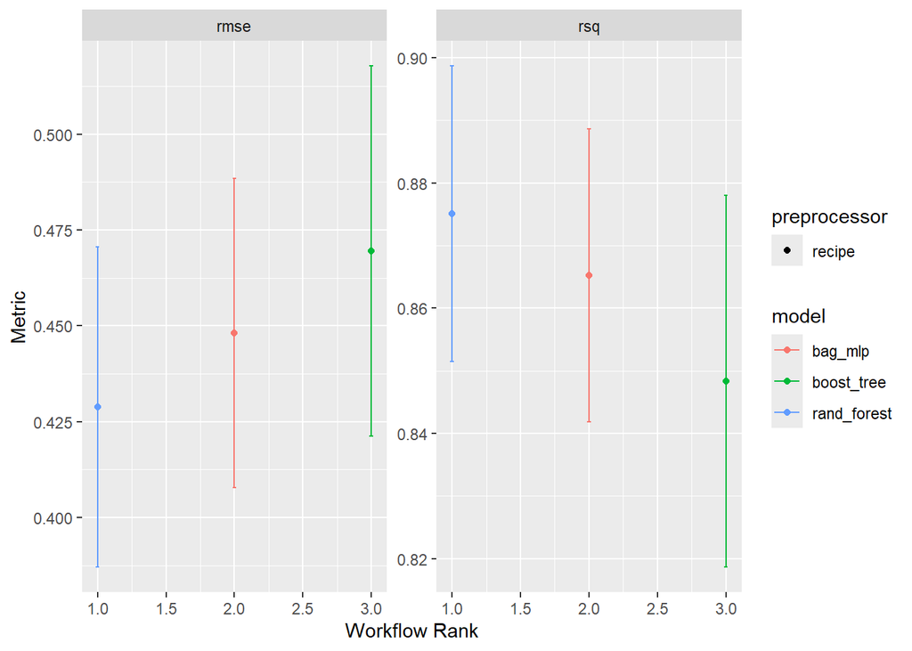

```r
autoplot(wf_fit) # use autoplot
```

```r
rank_results(wf_fit, rank_metric = "rsq", select_best = TRUE) # use rank_results to compare the models
```

```
# A tibble: 6 × 9
  wflow_id   .config        .metric  mean std_err     n preprocessor model  rank
  <chr>      <chr>          <chr>   <dbl>   <dbl> <int> <chr>        <chr> <int>
1 recipe_rf  Preprocessor1… rmse    0.429  0.0254    10 recipe       rand…     1
2 recipe_rf  Preprocessor1… rsq     0.875  0.0143    10 recipe       rand…     1
3 recipe_nn  Preprocessor1… rmse    0.448  0.0246    10 recipe       bag_…     2
4 recipe_nn  Preprocessor1… rsq     0.865  0.0142    10 recipe       bag_…     2
5 recipe_xgb Preprocessor1… rmse    0.469  0.0293    10 recipe       boos…     3
6 recipe_xgb Preprocessor1… rsq     0.848  0.0180    10 recipe       boos…     3
```

I think the rand_forest model would be best because it has the highest R-squared value, suggesting the strongest model fit.

step 6: exact and evaluate

```r
best_model <- workflow() %>%
  add_model(rf_model) %>%
  add_recipe(rec) %>%
  fit(data = camels_train)

# Make predictions
test_preds <- augment(best_model, new_data = camels_test)

# Evaluate
metrics(test_preds, truth = logQmean, estimate = .pred)
```

```
# A tibble: 3 × 3
  .metric .estimator .estimate
  <chr>   <chr>          <dbl>
1 rmse    standard       0.370
2 rsq     standard       0.892
3 mae     standard       0.228
```

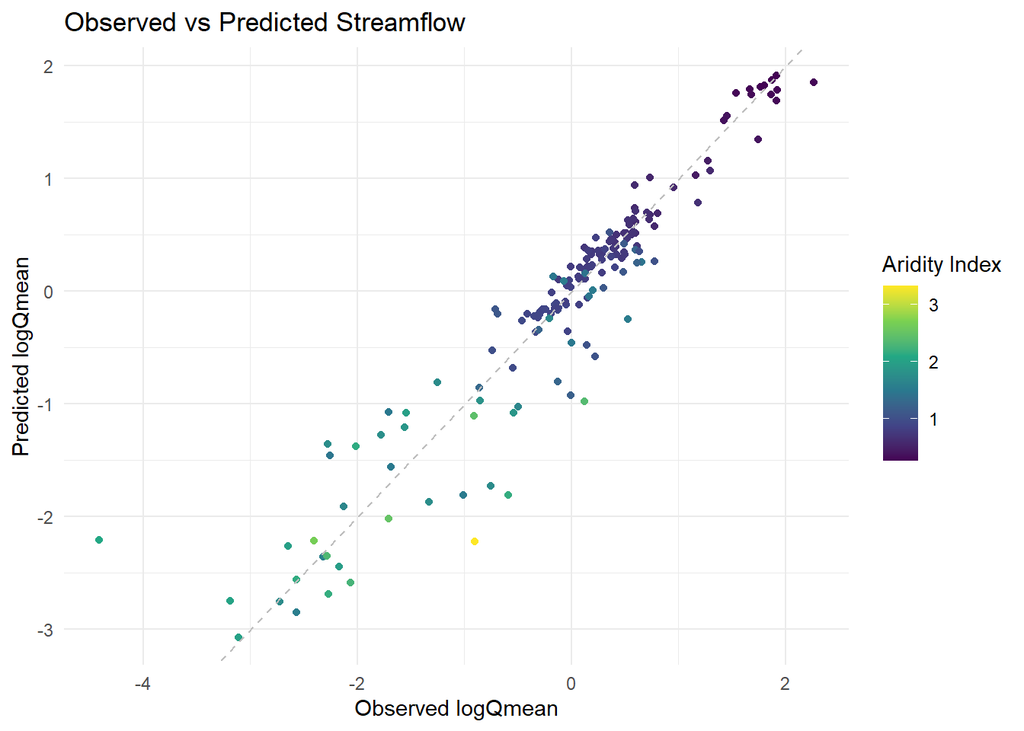

```r
#visualization
library(ggplot2)

ggplot(test_preds, aes(x = logQmean, y = .pred, color = aridity)) +
  geom_point() +
  geom_abline(lty = 2, color = "gray") +
  scale_color_viridis_c() +
  labs(
    title = "Observed vs Predicted Streamflow",
    x = "Observed logQmean",
    y = "Predicted logQmean",
    color = "Aridity Index"
  ) +
  theme_minimal()
```